# Datos Cuantitativos Agrupados

ASR

12/5/2021

## Datos Cuantitativos agrupados

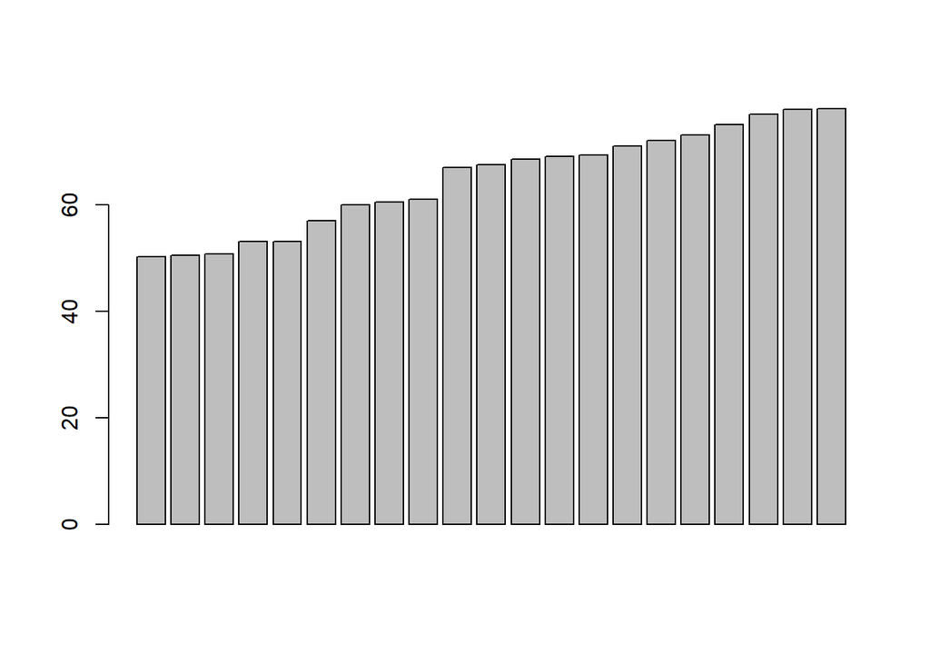

```r
pesos = c(50.2,50.5,50.7,53,53,57,60,60.5,61,67,67.5,68.5,69,69.3,71,72,73,75,77,77.8,78)
barplot(pesos) # Tal cual no dice nada. Hay que agruparlos
```

Agrupando decidiendo el num de intervalos, la amplitud de los intervalos, acumular extremos de los intervalos y calcular el valor representativo del intervalo. Su marca de clase. Usando hist().

Para los intervalos (k) a calcular se pueden hacer de distintas formas (k num grupos a dividir): - Regla de la raiz cuadrada: $k=[\sqrt{n}]$ - Regla de Sturges: $k = [1+log_2(n)]$ - Regla de Scott: Indica amplitud teórica.
$$A_s=3.5\cdot\tilde{s}\cdot n^{-1/3}$$
donde $\tilde{s}$ es la desviación típica muestral
$$k=\left[\frac{max(x)-min(x)}{A_s}\right]$$
- Regla de Freedman-Diaconis: 1º Amplitud teórica Afd y luego k.
$$A_{FD} = 2\cdot(Q_{0.75}-Q_{0.25})\cdot n^{-1/3}$$
$$k=\left[\frac{max(x)-min(x)}{A_{FD}}\right]$$

Ahora hay que definir la amplitud (A). Se puede dividir el rango entre k. Si da exacto tomaremos A+una unidad de precision.

Con amplitud se calculan los extremos. [L1,L2)[L2,L3) … Ej: El L2 está incluido en el grupo de la derecha no en el izquierdo.
$$L_1=min(x)-precision/2$$
$$L_2 = L_1+A$$
$L_i = L_1 + (i-1)A$ con $i=2,...,k+1$

Las marcas de clase están entre los intervalos siendo el punto intermedio.
$$X_1 = \frac{L_1+L_2}{2}$$

## Ejemplo práctico

### Calculo del numero de elementos con distintos metodos

```r
datacrab = read.table("../data/datacrab.txt",header=TRUE)
str(datacrab)
```

```
## 'data.frame':    173 obs. of  6 variables:
##  $ input : int  1 2 3 4 5 6 7 8 9 10 ...
##  $ color : int  3 4 2 4 4 3 2 4 3 4 ...
##  $ spine : int  3 3 1 3 3 3 1 2 1 3 ...
##  $ width : num  28.3 22.5 26 24.8 26 23.8 26.5 24.7 23.7 25.6 ...
##  $ satell: int  8 0 9 0 4 0 0 0 0 0 ...
##  $ weight: int  3050 1550 2300 2100 2600 2100 2350 1900 1950 2150 ...
```

```r
cw = datacrab$width
n = length(cw)
k1 = ceiling(sqrt(n)) # Regla Raiz cuadrada
k2 = ceiling(1+log(n,2))  # Sturges - nclass.Sturges(cw)
As = 3.5*sd(cw)*n^(-1/3) # Scott - scott(cw)
k3 = ceiling(diff(range(cw))/As)
Afd = 2*(quantile(cw,0.75,names=FALSE)-quantile(cw,0.25,names=FALSE))*n^(-1/3)
k4 = ceiling(diff(range(cw))/Afd) # nclass.FD(cw)
```

Regla raiz cuadrada k = 14

Regla Sturges k = 9

Regla Scott k = 10

Regla Freedman-Diaconis k = 13

### Calculo de los intervalos (Regla Scott)

```r
A = diff(range(cw)) / k3
A # Redondeamos al nivel de precisión que usamos. Si lo hacemos con un milimetro pues cambiamos a 1.3 (Para mantener la precisión de los datos)
```

```
## [1] 1.25
```

Redondeamos al nivel de precisión que usamos. Si lo hacemos con un milimetro pues cambiamos a 1.3 para mantener la precisión de los datos. A=1.3

### Calculo de Extremos

```r
A = 1.3
L1 = min(cw)-1/2*0.1
L = L1 + A*(0:k3)
X = L1 + A/2 + A*(0:k3-1)
L
```

```
##  [1] 20.95 22.25 23.55 24.85 26.15 27.45 28.75 30.05 31.35 32.65 33.95
```

```r
X
```

```
##  [1] 20.3 21.6 22.9 24.2 25.5 26.8 28.1 29.4 30.7 32.0 33.3
```